# NEFSC Acoustics Field Manual

Version 2025.06.10  
Jennifer McCullough, Annamaria DeAngelis, Rob McLean

# PURPOSE

## MAIN GOALS FOR REAL-TIME DATA COLLECTION

1. **Get accurate start/end times of all species encounters**
2. Determine overlap between acoustic groups and visual sightings of delphinids, so that we have acoustic encounters identified to species as often as possible.
3. Collect group vocal period information for Gervais’ beaked whales (high quality recordings of Gervais’ needed)
4. Collect high quality recordings of Kogia species and get group vocal period information
5. Mark start and ends of sperm whale vocal activity
6. Capture the changing environmental conditions/situations

## GENERAL DATA COLLECTION PROCEDURE

We will be using Pamguard to collect and record data. There is both an aural (sperm whales, some dolphin whistles and clicks), and visual component (spectrogram, click bearing-time display), data entry form, and incoming sightings information on a separate computer, so your attention needs to be diverted amongst multiple screens and incoming information. Please keep in mind that while you will hear sperm whales and dolphin whistles, you often will not hear echolocation – the aural component is to reduce the stress of what to pay attention to on screen. Sperm whale start/ends can be assessed aurally, and for dolphins, serve more as a cue.

# START OF CRUISE

## MAINTAIN LOGGER LOOKUP TABLE

In the steps below, you will be generating a blank database specific to each cruise that will contain all of the information pertaining to the modules in your Pamguard settings file. This blank database however, will not contain the historical record of the field options for the Logger forms (printscreens of these forms are in Appendix I). To use those options (and create new ones) requires you to upload the master Logger form into your new database. The master Logger form is Logger_UDF_20190814_Blank_NEFSC.sqlite3. Please take care when editing this file, as this is the basis for all cruises.

CONTENT DESCRIPTION

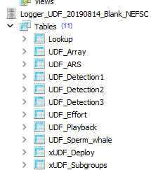

All tables starting with “UDF” equates to a Logger form that an analyst can fill out to record cruise metadata and detection data. If there is an “x” preceding “UDF”, it means that form is invisible to Pamguard, but still retained in case you ever need to use it. Check to make sure that the forms you need for your cruise are active in the Logger file (the above printscreen are the tables that need to be active for abundance surveys).

LOOKUP TABLE  
The Lookup table within the Logger_UDF_20190814_Blank_NEFSC database contains all the reference material to populate the Logger forms. Field definitions are as follows:

**Id**: has to be a unique ID number. Please sort this column (click on the column header) to see what the last number used is. You’ll see there are gaps within the sequence. For now, please do not use these skipped numbers, as we’re still working on migrating the older cruise data to be compatible with this system.

**CopyId**: do not need to worry about this one. Can be left blank/null.

**Topic:** general theme the field relates to. Typical ones that are edited are “Who”, “species”, “cruise number”.

**DisplayOrder**: order in which the row should show up in the drop down menu in the Logger form. Does not need to be unique within the database, but needs to be unique within a Topic.

**Code:** Does not need to be human readable. Should be a shortened code of the ItemText that will be stored in the database tables. Displays in the dropdown menu within the parentheses.

**ItemText**: the human readable short description of what that row is. Displays in the dropdown.

**isSelectable**: a binary 1/0 to let Pamguard know whether to show that row in the Logger form in Pamguard (1) or not show (0)

The following steps should be done **prior** to the cruise

1. Make sure that the acousticians who are participating in the cruise are listed within Logger_UDF_20190814_Blank_NEFSC. If not, you can add them by inserting a new row using the green + button and filling out the Id, Topic, DisplayOrder, Code, ItemText, and isSelectable fields. The code should be the acoustician’s initials.
   1. If there are acousticians in the table that are not going out on your cruise, toggle them from 1 to 0 under the “isSelectable” field
2. Make sure that the cruise name is added to the table. This is under the “cruise number” Topic. The standard NMFS cruise code should go under Code [Ship 2 or 3 digit identifier][Last 2 digits of the year the cruise is being conducted][2 digit number referring to the order your cruise is for that particular ship]
   1. Toggle off any previous cruises that are still marked as 1 under “isSelectable”
3. There are more fine scale edits that can be made to this table, but please check in with Annamaria if you are going to do so

When returning from the cruise, make sure that any additions you made are copied into the master database located on the server. Check in with Annamaria that you have done so, or need help.

## DRY LAB SETUP

1. Towed Array Order of Connection
   1. Tail, End Array, attach to tow cable
   2. Tow cable and array in full deployed are attached to the deck cable
   3. Deck cable plugs into the front of the Acoustic Recording System (ARS)
   4. ARS sound cards plug into the Recording and Tracking computers via black USB cables
2. Power connections for Towed array
   1. White power cord at the back of the ARS. Plug into ship’s UPS strip
3. Depth sensor
   1. White USB cable from the back of the ARS. Plug into the Recording computer

# START OF LEG

## DRY LAB COLD START UP: TOWED ARRAY

1. Starting with everything OFF
2. Power up Recording and Tracking computers
   1. Login to encryption (if applicable)
   2. Login to Admin profiles
      1. Select the key icon to access the login
   3. Update time on computers at beginning of the Leg (UTC)
3. **Configuring the computers to read the ship’s GPS**
   1. Use the serial to USB adapter cables (Keyspan Tripp-Lite)

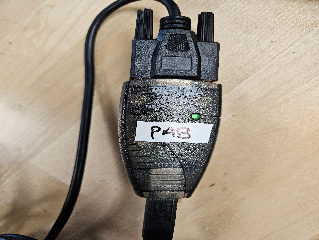

[figure not shown]

[figure not shown]

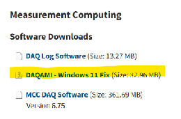

         3. Install the Windows 11 fix (you will need to restart your computer)
         4. You know the computer is reading the depth sensor when you sign back into the computer and a pop up window appears saying that there’s a new hardware device connected. You may need to turn the ARS on/off to get it to recognize the depth sensor

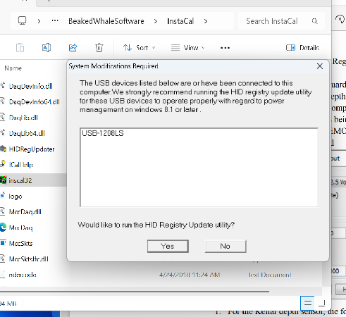

         5. Make sure the depth sensor is being seen under the PC Board list, and that it doesn’t just say DEMO-BOARD

[figure not shown]

         6. Once you see [USB name] in the Instacal tree, Pamguard should be able to read the depth sensor (“Select measurement device” should no longer be blank in Pamguard)
      2. Configure depth readout in Pamguard

[figure not shown]

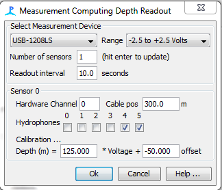

         1. For the Kellar depth sensor, the format should be 125 with a -50 offset. Voltage should be set to a +/- 2.5V scale
         2. The pressure should be around 0.4 with the array on deck. If it is not, check the array for possible air bubbles near the depth sensor
6. **Tracking Computer**
   1. Open PAMGuard on the Tracking Computer (right-click on the PAMGuard.exe in the folder on the Desktop > Run as administrator) (otherwise you cannot sync the GPS clock with the PC clock)
      1. C:\Users\paadmin\Desktop\PC2501\ PAM20210_PC2501_Leg1_settings.psfx
      2. Click OK
      3. Check MAP that GPS data is highlighted by a black box. If red then GPS is bad. Check connections
      4. ONLY @ Start of Leg: Create a new database
         1. File → Database → Database Selection
         2. Click “Browse / Create”
         3. Rename file with format [Data owner]_[Region]_[Deployment date YYYYMM]_[Cruise code]_[Leg#]_Tracking and click OK
         4. Pop Up: Click OK to generate a blank database
         5. Click OK
      5. ONLY @ Start of Leg: Add Logger forms
         1. Settings → Logger Forms → Regenerate all forms
      6. File → Save Configuration and Exit
      7. Return to step 6a and start up PAMGuard

# INFORMATION WHILE UNDERWAY

## TOWED ARRAY: DEPLOYMENT AND RECOVERY

### MORNING

1. 1. Contact Bridge via phone for deck dept to come to the back deck for deployment (*Bigelow* only, *Pisces* bridge will contact acoustics and deck crew).
   2. Chief boatswain will run the winch, and two deck crew will assist the science party in carrying the array and weighted sections of deck cable to the stern.
      1. Care should be taken to avoid scraping the array and taped sections along the deck because it will tear the tape and expose the bare lead weights.
   3. If needed remind bridge to remain in a straight line for deployment
      1. Can deploy at speeds between 5-10 knots (5 is always preferred if possible) as well as between 2-3 knots if there’s too much tension on the wire
      2. Do not deploy array in waters less than 100 meters
   4. Always wear a life jacket when doing any over-the-side work on the ship, such as hand deploying the array off the stern.
   5. Fully deploy array
      1. Hand deploy tail, end array, and weighted section starboard of the fantail
         1. 2 people should handle the oil filled section (at least one person should be an acoustician)
         2. One person stands at the end of the ship and lowers the array into the water, the second person is feeding the array to the person standing at the end.
         3. Make sure that the tail is tending away from the ship and not underneath before lowering the array into the water.
         4. Take care to avoid knots and tangles, a kink in the deck cable could break it.
      2. Deploy rest of cable via the winch. Make sure the cable streams off the exercise mat on the roller.
         1. If the cable is bouncing excessively, ask the bowswain to slow the winch.
         2. Net reel operator: deploy the array such that the connector aligns with the railing for the acoustician to connect to once the array is fully deployed.
      3. Run your hand on the cable to check for any abrasions, loose tape (remove those pieces)
      4. One person should be guiding the cable so it doesn’t get caught on deck and stays on the rubber mat
      5. Yellow tape= 100 m marker, white tape= 25 m marker. If multiple lines of either color, add to get the total e.g. two white lines= 50 m
      6. Connect 2 lines with carabiners to the Yale grip and center the array streaming off the ship. Secure the lines to aft cleats so that tension is on the yale grip lines and not on the deck cable. The yellow wrapped section of the tow cable should be aft of the fantail, which is used by the NOAA Corp officers to monitor the array’s angle during turns

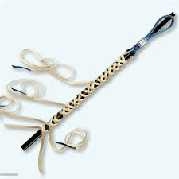

      7. For a demonstration of the deployment process, please refer to [Acoustics_DeployArray.mov](https://drive.google.com/file/d/1BrI26e88_hM-_RTuMnp1aSpijOBN1VIN/view?usp=drive_link)

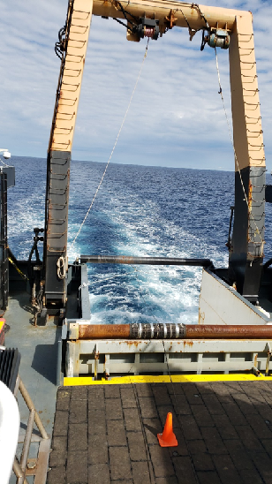

         Example setup on the Bigelow
   6. Connect deck cable
      1. The tow cable is appropriately connected when you can see the O-ring through the pinhole on the side of the connector.
      2. Each connector on the array has an O-ring. The O-rings in the gold caps and in the connector for the tow cable are loose and fall out easily, please watch for this. If an O-ring falls out, clean off any grit and replace it. If an O-ring is lost, there are spares of several sizes in the toolbox in the lab.
   7. Turn on the ARS
   8. The TerraMaster should already be on, turn on if not
   9. Get sound speed from the dawn CTD cast, which should be on oceanography’s data entry form behind the acoustics computers. The sound speed in Pamguard’s Hydrophone array module should be for depth at 10m (they will give you 5, 10 & 15m upcast values). If you find you are not towing at this depth 1) add/subtract lead from the tow cable before 2) talking with oceanography about changing what depth you need.
   10. Open up PAMGuard on both Recording and Tracking computers
       1. Start Pamguard v.2.02.10 with admin rights by selecting the Pamguard 2.02.10 folder on the desktop and right click on the Pamguard.exe> Run as administrator
          1. If Pamguard says that the PC clock is off from the GPS clock, go to Settings > GPS Processing > Update PC Clock. You’ll see the two times listed. Click on “Set Now” to sync them. They may be out of sync by 1 s but that is ok. Click on Close.
       2. Enter in the latest sound speed under Settings > Hydrophone array manager before pressing “run” on the Tracking computer
   11. Hit run on Recording computer (Red button)
       1. Double check green bars in PAMGuard dance and is writing to file
          1. You should be recording Continuous data. You should see some information appear with the file duration, file size. Also checkboxes for up to 3 channels should be selected
       2. Make sure you can see the depth information come in and that it is as expected.
          1. While the array is on deck, the voltage should read ~0.4V and ~0.5 m. When the array is deployed, the voltage values should be between 0.4-0.5V.
          2. If seeing voltage values around 1.3V, change the first value in the equation from 125 to 38 under the Hydrophone depth readout (for Keller)
          3. If seeing voltage values around 1.8-2V, change the first value in the equation from 125 to 30 under the Hydrophone depth readout (for Keller)
   12. Hit run on Tracking computer (Red button)
       1. Fill out Logger forms for Effort. Add “SOD” (Start of day) and “EOD” (End of day) in the User comments. If Array or ARS settings have changed then fill them out as well.
       2. Use the “Other effort” field to note the echosounder status

### EVENING

2. 1. Take Acoustics OFF effort by updating the Logger Form
      1. Hit F1 to record time. Choose “off effort” for Visual and Acoustics and Recording. Hit SAVE.
   2. Communicate with the Bridge about recovering the array- the Bridge should slow to 5 knots or less and alert the deck dept
   3. Click the PAUSE button on PAMGuard for both Tracking & Recording computers
   4. Turn the ARS off
   5. Make sure all data is saved in Logger forms on Tracking computer
   6. Save and close PAMGuard on both machines
      1. File → Save Configuration and Exit (second from bottom)
   7. Proceed to back deck to (2 people) to pull in the array
      1. Needs: lifejackets, gloves, end caps (hard hats as well if working on the *Bigelow*)
      2. Make sure to disconnect the tow cable from the deck cable up on the net reel prior to using the winch.
      3. Make sure the tow cable’s connector is firmly duct taped to the inside of the winch drum when bringing in the array. The connect cannot be banging against the drum
      4. Reel in the cable until someone spots the oil filled section. Once they have the oil filled section they will hand pass it to the next person standing beside them and the two will bring the array on deck, making sure the weighted section of cable is not dragging on the deck.
   8. Proceed to Towed Array Data: QAQC & Backup
   9. Do not close down/shut down the laptops, it will mess up the PC clock time

## TOWED ARRAY: REAL-TIME MONITORING PROCEDURES

### PRIORITIES

1. Recording!! Make sure that sound files are being written to the hard drive (TerraMaster). Take a look at the sound files after the first day, make sure everything is looking OK.
2. Log effort- when the array is in the water and recording, when there are acousticians on effort, visual team on effort, Beaufort every hour (when visuals are off effort), echosounder status, trackline number.
3. Annotate the start and end times for groups of dolphins, localize on groups and correlate acoustic ID with visual ID when possible by comparing acoustic bearing and distance with visuals’ information. If the positions seem to match well, make a note of this and assign the FB# (flying bridge sighting #) to your acoustic event. You can use the Visual Angle to Array module to assist with this. This needs to be calibrated at the start of each cruise by tracking the same group visually and acoustically.
4. If not busy, track beaked whale clicks. At the beginning of the survey you may be asked to track beaked whales to help the observers train their eyes on identifying beaked whales at sea. If it’s too busy, mark down the start and ends of beaked whale vocal periods.
5. Mark down start and end times of sperm whale groups, along with the click types heard and a rough estimate of the number of individuals in the comments field. No need to localize them, that is better done in post-processing.
6. Keep an eye on the high frequency click bearing-time display (Recording computer) for Kogia clicks. If a solid click train is coming in you should radio the Chief Scientist to ask for either an acoustic focal follow or to slow the ship down to 7 knots. Please track Kogia if not busy with dolphins or other species, and at a minimum enter their start/end times in the database.

### GENERAL OPERATIONS

1. The passive acoustic system should be in the water and running at all times when the visual team is “on-effort”. At times, the hydrophone array may be left in the water to continue collecting data when the visual team is “off-effort”; these decisions will be made collaboratively with the chief scientist and acoustics team.
2. Passive acoustic observers will rotate between “on” and “standby”. The standby person should keep a walkie talkie on (channel 3) in case the on-effort person needs them (bathroom break, busy time).

### TRACKING PROCESS

1. Tracking animals will be done primarily through the click detector. Once you see a click train (3-5 consecutive clicks along the same bearing), start a detection in the Detection tab. Hit F1 to enter the time & date. Hit F1 to enter the Lat/long. Enter the Acoustic ID # along with at least the initial bearing angle. You can fill out the other fields as the event goes on. There are 3 Detection tabs so that you can track 3 things at once. You can also use the TD tab to localize whistles.
   1. For encounters in which there are both bearings from the whistles and clicks, you can merge them into one event by going to the map, holding down CTRL + left click and select “Assign X bearings to UID#”. You should then see both the whistle and click bearings as the same color. You may need to repeat this step over the course of the encounter.
2. A mark should be placed at the start position on the trackline of the initial bearing location- clicks don’t stay on the map for long, the markers will last longer. Double click the spot on the map to enter “start of A#- [species]”
3. Measuring the perpendicular distance from the ship’s track to the marked location can be done in the Map tab, by double-clicking next to the map comment and click + hold to the convergences (note: if you happen to select the pixel the map comment is on Pamguard won’t draw the measuring line). If you have R and L locations, measure on both sides of the ship’s track and take the average distance (this will be the beam distance). If you only have one location, take all measurements from the trackline to that location. Also measure the distance from the ship’s track along the first angle plotted that converged at the location (the first detection distance).
4. Can you tie this detection to a visual sighting?? If so, be sure to record the visual ID, and any other info from the visual team in the comments field (time, bearing, distance, species ID, etc.).
   1. Use the Visual to Array Angle module and the incoming information from the flying bridge to do so
5. For marking the end of a detection, follow these general guidelines
   1. Sperm whales: until 5 min have passed where no clicks are detected (can feel free to press F1 prior to this but keep the detection tab open for another 5 min)
   2. Beaked whales: get an end time when 1 minute has passed without clicks. You will probably need to press F1 a few times as the clicks come back (thus constantly updating the end time)
   3. Dolphins: if it’s just clicks, the end time is within 30s of the last click train. If it’s whistles and clicks, keep the detection open for up to 2 min after the last whistle. It’s common for whistle presence to come in and out
6. Click “Save” to save this detection to the database.
   1. If you end the encounter prematurely, you can double click on the row below the form to make any changes. Note that the F1 features do not work in this view. If the encounter’s row is not visible, you can make a comment using an asterisk (*) in the User Input for later modification during the QAQC process.
7. Look/listen for new groups. Continue to check bearings to sounds. Sometimes you will pick up a new group ahead of the ship while you are still hearing a group behind the ship. Start a new Acoustic ID when another group is detected. If a second group is detected before you have stored the info about the first group, you can save the first group and start a new group, then go back and edit the info for the 1st group when time allows. Make note if long periods occur with no acoustic activity (i.e. “AQ”).

For further details, please refer to the [Towed-Array_Real-time-monitoring_Demo.mov](https://drive.google.com/file/d/1L_jzXDLn9wkzW6z8CoYT2w2QFW1TlhlT/view?usp=drive_link) for a simple, single species, 1 group example, and [Too_many_dolphins-pt1](https://drive.google.com/file/d/1XIQCdE2jplXBVlQxQgKRh_KO3pjuEM0l/view?usp=sharing) and [pt2](https://drive.google.com/file/d/135-hvLQd7R7Ahctv6yMKyVXXI2W_TnP-/view?usp=drive_link) for an example of when there’s too much going on to track.

## TOWED ARRAY: DATA QAQC & BACKUP {#towed-array:-data-qaqc-&-backup}

### Tracking Computer

1. 1. Clean up edits at the end of each day
      1. Open SQLiteStudio from the task bar (silver icon)
      2. Look at tables for current cruise Leg
      3. Tables to check are Detection (1,2,3), Effort, Sperm whale, UserInput, Map comments
         1. Open table (double click), then select the Data tab
         2. Scroll to bottom and/or advance page to end for latest data entries
         3. Detection (1,2,3): Use notepad ID numbers to check AC_ID count and all relevant fields. Where localizations were impossible, the entry should have NA
         4. Sperm whale: should have at a minimum a start and end time, start and end lat/lon, click types heard/seen, and estimate of number of animals in the comments field
         5. To edit a field - double click and it will turn blue, click once more in the field, then the cursor will appear and you can edit. Click on the **GREEN** check box to commit the edit. Click the **RED** X if you want to restore the field to its original value.
         6. R-Click on lower bar and select Close all windows
      4. Make sure all fields are filled in and Acoustic ID numbers have not been skipped
      5. * in front of any comment signifies a correction is needed
         1. Add **(DONE)** to the beginning of all * fields that have been corrected
   2. Insert NEFSC_48 hard drive into computer
   3. Go to E:\AMAPPS 2025 Backup\Pamguard_Binaries_Databases
      1. Make copies of the day’s database with the date (ex. NEFSC_NE-OFFSHORE_20250110_PC2501_Leg1_Tracking.sqlite3)
      2. Copy the days Binary files, and Database to Acoustics NEFSC_48 hard drive under the respective computer’s folder
   4. Update daily summary of acoustic detections NEFSC_NE-OFFSHORE_202501_PC2501_Acoustic-Detection-Summary
      1. Backup to the external hard-drive under Cruise_Summary
   5. Update daily notes in the cruise log PC2505_Leg#_PAM_Cruise_Log
      1. Backup to the external hard-drive under Cruise_Summary
   6. Save daily print screen power point
      1. Backup to the external hard-drive under Daily_Printscreens

### Recording Computer

2. 1. Go to E:\AMAPPS 2025 Backup\Pamguard_Binaries_Databases
      1. Make copies of the day’s database with the date (ex. NEFSC_NE-OFFSHORE_20250110_PC2501_Leg1_Tracking.sqlite3)
      2. Copy the days Binary files, and Database to Acoustics NEFSC_48 hard drive under the respective computer’s folder
3. TerraMaster
   1. Check that the internal hard drive has enough space for the next day; change drives if they will run out of space.

## TOWED ARRAY: ACTIVE ACOUSTICS

An active acoustic system (e.g. EK80/echosounder) will be alternated between “ON/ACTIVE” (1200 – 0700) and “OFF/PASSIVE MODE” (0700 – 1200) daily. This is because beaked whales exhibit an acoustic response to echosounders thus we need to balance collecting passive acoustic information on beaked whales, with the need to collect prey layer data from the echosounder, which has been found to be a useful covariate in some species models. The survey technician on board is responsible for changing the echosounder state, however, it is your responsibility to VERIFY that the EK80 has been turned to passive mode based on the proposed schedule. If it has not, find the survey tech and kindly ask them to turn it off.

## TOWED ARRAY: INFO FROM VISUALS

1. Sighting Info
   1. Sighting #
   2. Time (note that it will be in local time)
   3. Bearing angle
   4. Distance (any unit is fine, there is a conversion chart in the dry lab)
   5. Species
2. Vessels in the area
   1. Acoustics can ask the Bridge if there is a vessel in the area
   2. Get bearing angle and distance for the comments
3. Sperm whales & beaked whales
   1. Good reminder for Visuals is to ask for when animals fluke (sperm whales) or exhibit a high arch (beaked whales)
      1. This is only allowed once visuals has this animals and is off effort
4. Gear
   1. Ask Visuals to report any gear seen in the water and help the Bridge avoid passing the towed array through it.
5. No Fishing from crew while the array is in the water

## TOWED ARRAY: DRIVING WITH ARRAY IN THE WATER

1. The tow cable should NEVER be 90 degrees from the back of the ship!
2. While turning, the tow cable can be up to 45 degrees in relation to the fantail.
   1. The ship can turn at angles greater than 45 degrees, but all turns larger than 45 degrees need to be wide in order to maintain smaller angles from the ship.
   2. No need to slow the ship for turning
3. Williamson Turn: Allows the ship to do a 180 degree turn and come back down the existing trackline.
   1. If Acoustics requests this turn, then make sure to ask the Visual team if a turn to the left or right is better based on the conditions. If at all possible try not to turn the Visual team into the sun’s glare.

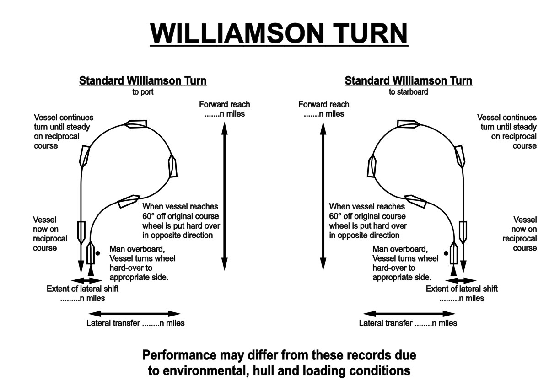

## TOWED ARRAY: CHANGE IN SIGNAL

1. Complete loss of signal (Sound)
   1. Contact Chief Scientist
   2. Confirm that you can hear nothing directly from the NiDAQ sound cards with multiple sets of headphones
   3. If there is no resolution, contact Bridge and Flying Bridge to slow the ship to 5 knots for towed array retrieval
   4. Have someone get a 5 gallon bucket and bag of 3M diapers in case the array is leaking oil. Be careful when bringing it on deck.

## DASBR: INSTRUCTIONS

1. SELECT ALL of the following components to build out a DASBR and record their ID’s in the DASBR deployment sheet on the clipboard. Every component has a unique identifier.
   1. SolarOne GPS
      1. Place the GPS unit on the back deck to charge at least one day prior to deployment
      2. Confirm it has checked in on the LoneStar website
   2. High flyer
      1. Make sure GPS unit and strobe light are attached via zip ties
      2. Confirm “if lost” info is readable on the side of the buoy
   3. Back Bone
      1. Pull a storage box with 150 m of back bone line, bungee, mid-water trawl float, 2 hydrophones with black mounts, one SoundTrap clear bracket
   4. Weight
      1. Select a 30 lb weight and they don’t have ID numbers ;)
   5. SoundTrap
      1. Confirm charge value and memory available is 100%
      2. Deployment settings complete
         1. 5min files
         2. Maximum sample rate (each SoundTrap has a different recording capability)
         3. Record using remote
      3. Plug in hydrophones to SoundTrap. Hydrophone 1 = HTI-96-Min, smaller head, Hydrophone 2 = HTI-92-WB, larger head
      4. All ports should have something plugged into them. (2) hydrophones and (3) dummy plugs
      5. If collars are available, put them over the dummy plugs. Make sure to remove them after every deployment.
   6. FPOD
      1. Insert 10 D cell batteries and mini-SD card
         1. Settings on SD card should be set so that the pod receives data from all angles
      2. Deploy upside down. Attach to the blue steel line using a thick black zip tie on the end with the holes, and a hose clamp on the other end
   7. TDR
      1. Set to record depth every 30 s
      2. Attach to the blue steel line 1 m above weight using skinny zip ties
2. Deployment and Recovery
   1. See [2024_DASBR_Deployment-Retrieval_Instr_forShip.docx](https://docs.google.com/document/d/1e3CeccWtDSBIu1W0rEp3kvZlAUy8HdIL_T1Ccq3BTw8/edit?tab=t.0)

# END OF CRUISE

## ARRAY CARE

1. Wash the array and tow cable with a hose (not on high power)
2. Remove all tape from the connector connecting the array to the tow cable as well as at the tail. Remove the tail
3. Bring the array to the wet lab and begin array spa
   1. Using a q-tip and alcohol, clean out any salt/water inside the connectors
   2. Can also use canned air
      1. Try not to spray it directly on the o-ring so that it doesn’t become brittle
   3. Look for corrosion and be sure to remove it
   4. Do not bend the pins
   5. Clean the caps as well, removing all salt residue
   6. For a demonstration of this process, please refer to [Acoustics_CleaningArray.mov](https://drive.google.com/file/d/1Ti1M_cINw-5IzJ1vR0UbfwU4s1-1wu_h/view?usp=drive_link)
4. Once dry, secure it in its pelican case
5. Be sure to also clean the connectors connecting the tow cable to the deck cable in the same manner
   1. Rinse off any part of the deck cable that was exposed to the elements
6. Spool the tow cable onto the wooden drum using two jackstands and a pipe
   1. Make sure both connector ends are visible/easy to access

# APPENDIX I: [Pamguard Field Tips and Tricks](https://docs.google.com/document/d/1gWdJaeLZlmnIQOD7a-zrQArYO1_9oHDu/edit)

## TOWED ARRAY: LOGGER FORMS

1. Overall NOTES:
   1. Make sure that Function keys are locked ON
   2. Hold “fn” key and press “Esc” to activate
   3. Important on newer computers
   4. Always fill out Date/Time on each sheet
2. ARS

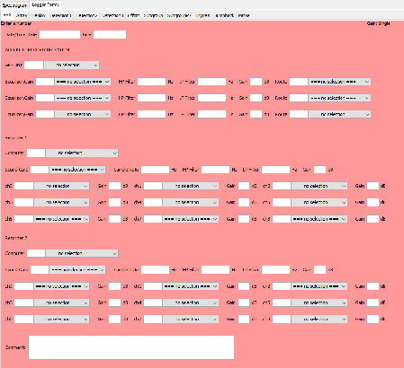

   2. Fill out at start of each Leg and then only if something changes in the Leg
   3. Acoustic Recording System
      1. Settings that impact the entire ARS
         1. GPS Unit: Shipboard GPS
         2. Leave rest blank
   4. Recorder 1 (Recording)
      1. Settings for each system
         1. Computer - Recorder computer
            2. Sound Card - NiDAQ
            3. Sampling Rate - 500000 Hz
            4. High pass - 1000 Hz
            5. Fill out each channel and the dB level assigned within PAMGuard module Sound Acquisition (Toolbar: Settings -> Sound Acquisition)
   5. Recorder 2 (Tracking)
      1. Settings for each system
         1. Computer - Tracking
            2. Sound Card - NiDAQ
            3. Sampling Rate - 250000 Hz (There is a decimator in place)
            4. High pass - 2000 Hz
            5. Fill out each channel and the dB level assigned within PAMGuard module Sound Acquisition (Toolbar: Settings -> Sound Acquisition)
   6. Click SAVE
3. Array

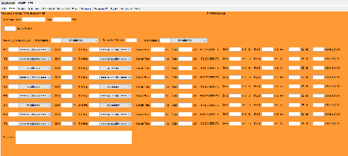

   2. Fill out at start of each leg and then only if something changes in the Leg
      1. Array Weight: 30 lbs
         2. Array Name 1 - Echidna array selected
            3. Separator - 0 m
            4. Array Name 2 – leave blank
            5. Leave rest blank
            6. Click SAVE
4. Deploy (not used)

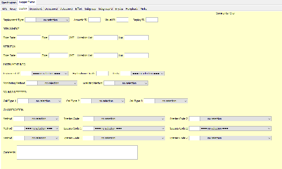

5. Detection (1,2,3)

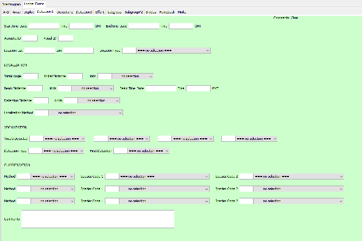

   2. There can be up to 3 active detections at one time using the forms
      1. If all you are is waiting on an End Time to close the detection and another form is needed, then Save the entry and put the End Time in the Comments Tab (ex: *End Time AC2 06/19/2023 12:12:12)
      2. All acoustic detection distances should be reported in meters
      3. To save the detection there must be a minimum of 3 signals (clicks or whistles) and at a minimum record the initial bearing angle.
         1. If never detected, write a note in the comments field that the encounter was “untraceable”
         2. If minimum is not met make a comment in the log with what was heard and when
      4. To signify a new group: incoming bearings must be at a smaller angle than the current group’s bearings you are tracking & the original group must be behind 90 degrees (this is because there are lots of individuals/subgroups and can be spread out)
         1. Eg: you are tracking a group and they are at 108 degrees +/- 10 degrees. New clicks come in at 20 degrees. These new clicks would belong to a new group
         2. For the following fields, underline= required field
   3. StartTime Date: Start of detection (auto fill using F1, but correct the time to the initial click or whistle detected on the tracking computer) by either clicking on the click in the T-B plot and reading the time off the waveform, or hovering over the end of the bearing line drawn on the map
   4. EndTime Date: Last signal (click or whistle) detected (auto fill using F1, but correct the time to the last click or whistle detected on the tracking computer) using the same methodology as in 5.c.i
   5. Location: Autofill with F1 within 2 minutes of start time
      1. If there has been more than 2 minutes from the StartTime to filling in the field then place this comment in the Detection’s comment box (*Edit Lat/Lon to StartTime). If you’ve made a map comment for the start of the event, you can get that value in data QAQC (*see map comment for position of A1)
   6. Acoustic ID: Start with 1 at beginning of cruise and continue counting until end of the project (do NOT start over each Leg)
   7. Visual ID: Sighting ID number from Visual time that matches current detection
      1. If never seen, leave blank
         2. Initial Angle: First angle detected from either a click or whistle
         3. Initial Distance: Location at start of localization
            1. If never localized then fill in NA for units
         4. Beam Distance: Perpendicular distance from the beam (90 degrees) of the array to the first subgroup of animals
            1. With timestamp
            2. If never localized then fill in NA for units
         5. Detection Distance: Greatest distance animals were detected from the array. That can be the same as Initial or Beam distance.
            1. If never localized then fill in NA for units
         6. Localization Method: If any of the distances were measured then select Pamguard, otherwise NA.
         7. Vocals detected: Select as many vocal types that were present at any point throughout the detection (order does not matter)
         8. Detection Type: Acoustics or Both. Never use Visual as an option for this field. All Visual only sightings can be recorded in the User input.
         9. First Detection: Acoustics, Visual, or Both (Whomever’s start time is earliest).
         10. Method: Acoustic Technician
         11. Species Code 1: Select species acoustics detects and fill out 2 & 3 if needed.
         12. Additional Method fields are to be filled out if Visuals has a species ID. They don’t have to match acoustics. Example: Visuals has Unid. beaked whale, but Acoustics detects Cuvier’s beaked whales. OR Visuals has sperm whales and Acoustics detects sperm whales & Unid. dolphins.
         13. Comments: Any additional information of note from the detection. If the field is filled then add additional information in the User input. Add the UID number so we can match the PAMGuard annotations to the Acoustic ID later
   8. Click SAVE
6. Effort

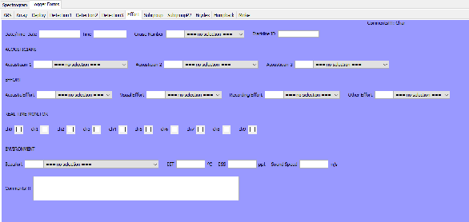

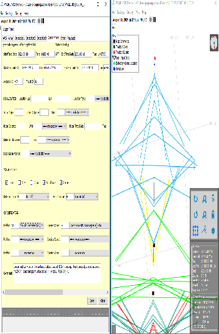

   2. Start/End Time
   3. Start/End latitude and longitude
   4. ID (46-Sperm Whale) and ID type (acoustic tech, visual, or both)
   5. Call type detected (Usual, Coda, etc)
   6. Localization not required, but feel free to practice if clicks registering on detector and nothing else is happening (NEFSC only).
   7. Comments should contain a rough estimate of how many sperm whales are in the event
8. Playback (NEFSC only)
   1. Refer to Appendix III link

# APPENDIX II: Species classification cheat sheets

## Atlantic

[Atlantic species decision tree](https://drive.google.com/file/d/1Y-JLa2RPE2i9B5ybSOadhdmEHgtZnYR0/view?usp=drive_link)  
[Pamguard click classification colors](https://docs.google.com/document/d/1i4Aj2YKW1od5Kjm_LlF2ItlrJXWbDNWZqzCSzyFwUCA/edit?tab=t.0)

## Pacific

[Beaked whale decision tree](https://docs.google.com/presentation/d/1GxxTSAwbIKcve0gfZaav-QwPWpIWKddL/edit#slide=id.p1)  
Pamguard click classification colors

# APPENDIX III: [Echosounder playback experiment](https://docs.google.com/document/d/1H4IobyDFi9HBQrA3Xo59i5nPyxcxwFy8/edit)

# APPENDIX IV: Off effort for beaked whales and Kogia

[Atlantic](https://docs.google.com/document/d/1Z8meXDJwnh3aN19hnlDu1D-j4Eui9t2v/edit)  
[Protocol for collecting high quality recordings of Gervais’ beaked whale](https://docs.google.com/document/d/1QzydwjWrPrkV_Dzt2m2O2cvoGykf9p0s/edit)  
[Pacific](https://docs.google.com/document/d/1a0b5M0YTH5oSo52oYkYmgtcdRKDHtgd0/edit)